# FigureYa283vennyPvalue

**Author(s)**: Xiaofan Lu; Yasi Zhang  
**Reviewer(s)**: Ying Ge  
**Date**: 2025-05-20

# 需求描述

# Requirements Description

主要是不知道这个韦恩图的p值是怎么实现的（exact test of multiset intersections）。

The P value below the Venn diagram is associated with the intersection (exact test of multiset intersections).

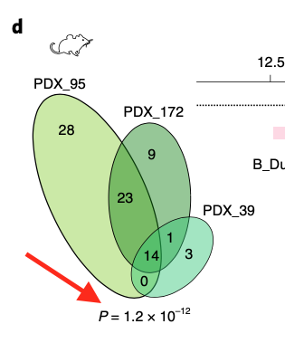

出自https://www.nature.com/articles/s41588-022-01047-6

图1 | 体内外三阴性乳腺癌中基底态持久细胞群的鉴定。 d. 图展示了三种PDX模型持久细胞中激活通路的交集情况（左），数据来源于MSicDB数据库的c2_curated（乳腺/乳房相关通路）和c7_Hallmark（特征基因集）两个分类。维恩图下方的P值代表该交集具有统计学显著性（基于多重集交集的精确检验）。条形图（右）显示了持久细胞中激活程度最高的五个通路（每个分类各选前五），横坐标对应PDX_95模型的-log10 q值。

Source: https://www.nature.com/articles/s41588-022-01047-6

Fig. 1 | identification of a pool of basal persister cells in TNBC in vivo and in vitro. d, Venn diagram displaying the intersection of pathways activated in persister cells from the three PDX models, among MSigDB c2_curated Breast/Mammary and c7_Hallmark pathways (left). The P value below the Venn diagram is associated with the intersection (exact test of multiset intersections). Barplot displaying the top five pathways (for each category) activated in persister cells (right). The x axis corresponds to –log10 q-values for the model PDX_95.

# 应用场景

# Application Scenario

韦恩图及p值计算（基于多个数据集交集精确检验，Exact test of multiset intersect）

Venn diagram and p-value calculation (exact test of multiset intersections)

# 环境设置

# Environment Setup

使用国内镜像安装包

Using domestic mirrors for package installation.

```r
options("repos"= c(CRAN="https://mirrors.tuna.tsinghua.edu.cn/CRAN/"))
options(BioC_mirror="http://mirrors.tuna.tsinghua.edu.cn/bioconductor/")
```

# 加载包

# Loading packages

```r
# 加载韦恩图画图软件包“VennDiagram”
# For drawing Venn diagrams
library(VennDiagram)
# 加载可求多个交集精确检验P值的软件包
# For calculating exact p-values of multiset intersections
library(SuperExactTest)
# 显示英文报错信息
# Display English error messages
Sys.setenv(LANGUAGE = "en")

# 禁止chr转成factor
# Prevent character conversion to factor
options(stringsAsFactors = FALSE)
```

# 输入文件

# Input Files

easy_input.txt，每个数据集为一列。这里以3个为例，可以有更多个数据集。

easy_input.txt, each dataset as a column. Here we use 3 as example, can have more datasets.

```r
# 读入测试数据 (这里为了简单演示，由26个英文字母生成三个数据集)
# Read test data (here using 26 letters to generate 3 datasets for demonstration)
dat <- read.table("easy_input.txt",sep = "\t", header = T, stringsAsFactors = F,check.names = F)

# 转化为列表数据类型
# Convert to list data type
dat <- as.list(dat)
n.bk <- length(unique(unlist(dat)))
```

# 计算p value

# Calculate p-value

输出多个数据集重叠显著P值，基于软件包“SuperExactTest”中MSET函数: Calculate FE and significance of intersection among multiple sets.

参考文献 Wang, M., Zhao, Y., & Zhang, B. (2015). Efficient test and visualization of multi-set intersections. Scientific reports, 5(1), 1-12.

Calculate p-value for multiple dataset overlaps using MSET function from “SuperExactTest” package.

Reference: Wang, M., Zhao, Y., & Zhang, B. (2015). Efficient test and visualization of multi-set intersections. Scientific reports, 5(1), 1-12.

```r
# x为定义的列表数据。n为背景群体数量，如基因总数，或这里的总的英文字母数26。lower.tail=FALSE表示计算上侧拖尾P值(统计量大于一个观察到的值概率)，即这里要计算的多个数据集重叠显著P值。
# x is the defined list data. n is the background population size, such as total number of genes, or here the total number of English letters (26). lower.tail=FALSE means calculating the upper tail p-value (probability that the statistic is greater than an observed value), which is the significant overlap p-value we want to calculate for multiple datasets.
mset.res <- MSET(x = dat,
                 n = 26,
                 lower.tail = FALSE)
p.value <- mset.res$p.value

# 打印pvalue
# Print p-value
p.value
```

```
## [1] 0.0006082805
```

# 画venn图

# Draw Venn diagram

个人比较推荐采用在线工具绘制scale后的韦恩图，方便快捷可编辑，可尝试以下链接： http://bioinformatics.psb.ugent.be/webtools/Venn/ http://bioinfogp.cnb.csic.es/tools/venny/index.html

这里用R画，用的是VennDiagram包。 还可以用ggVennDiagram包，标注各区域百分比，并且按百分比填充颜色，可参考https://www.yuque.com/figureya/figureyaplus/figureya112p。 如果有>=5个数据集，可尝试eulerrhttps://cran.r-project.org/web/packages/eulerr/vignettes/venn-diagrams.html或nVennR包https://cran.r-project.org/web/packages/nVennR/vignettes/nVennR.html

Personally recommend using online tools for scaled Venn diagrams, easy and editable: http://bioinformatics.psb.ugent.be/webtools/Venn/ http://bioinfogp.cnb.csic.es/tools/venny/index.html

Here we use R with VennDiagram package. Can also use ggVennDiagram package to show percentages and color by percentage, seehttps://www.yuque.com/figureya/figureyaplus/figureya112p. For >=5 datasets, try eulerrhttps://cran.r-project.org/web/packages/eulerr/vignettes/venn-diagrams.html or nVennRhttps://cran.r-project.org/web/packages/nVennR/vignettes/nVennR.html

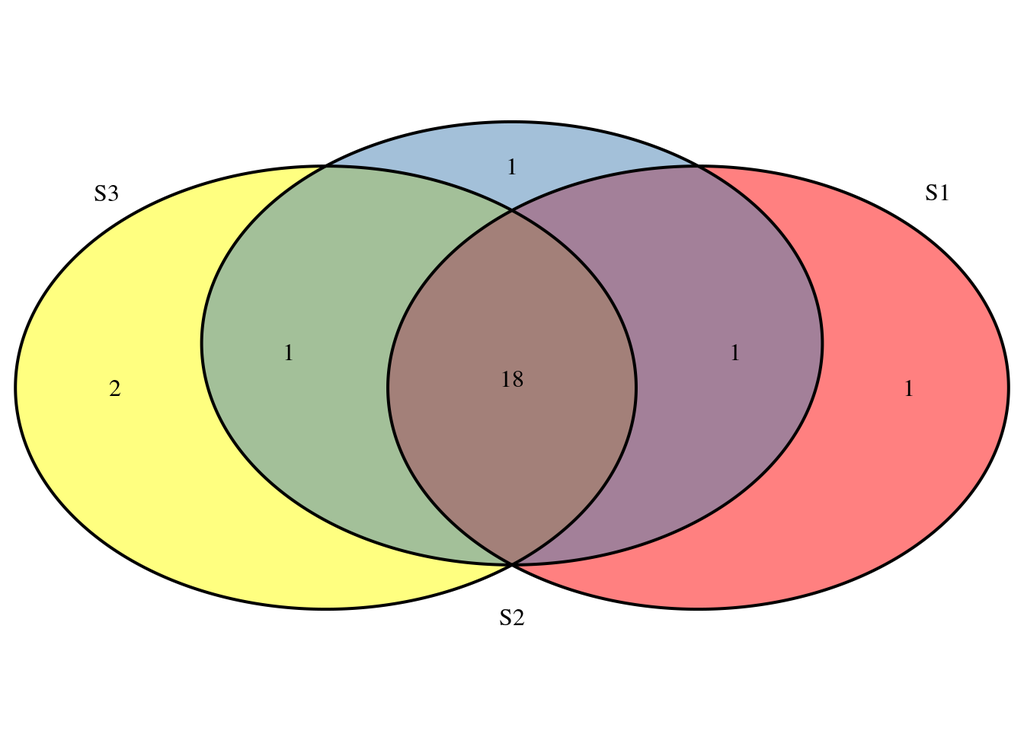

```r
# 创建韦恩图对象
# Create Venn diagram object
venn <- venn.diagram(x = dat,
                     filename = NULL,
                     fill = c('red','steelblue','yellow'))

# 初始化新图形页面
# Initialize new graphics page
grid.newpage()

# 渲染韦恩图
# Render the Venn diagram
grid.draw(venn)
```

```r
# 导出PDF文件（5x5英寸）
# Export to PDF (5x5 inches)
dev.copy2pdf(file = "venny.pdf", width = 5, height = 5)
```

# 会话信息